# KEY 02 intro R

## GRADED

2.3 Make a basic boxplot with the `blength` data on the y-axis, and the `species` information on the x-axis

- Hint use the `plot()` function. We will use `ggplot()` in part 4 below.

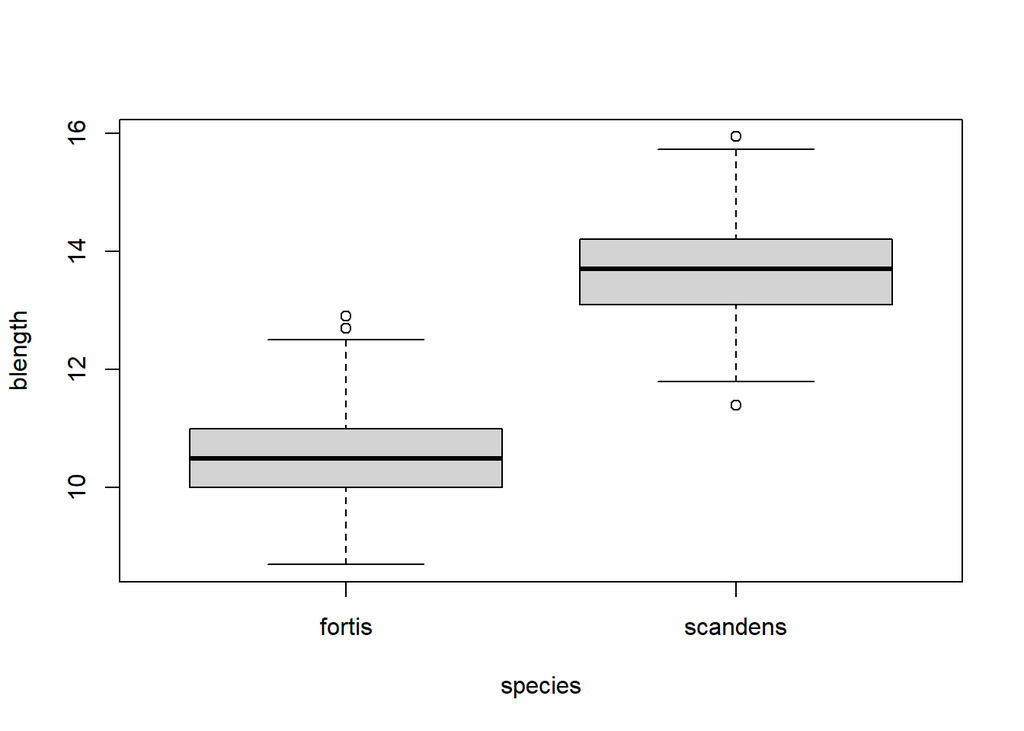

```r
### GRADED 0.5 points ####
plot(blength ~ species, data = finch)
```

2.4 Add a comment describing what you see.

```r
# not graded
# just look that students are properly interpretting plot
# Means of species are different - height of median line in box
# Generally look normally and symmetrically distributed within species
```

2.5 Make a basic plot showing the relationship between `blength` and `bdepth`

- `bdepth` is for “beak depth”

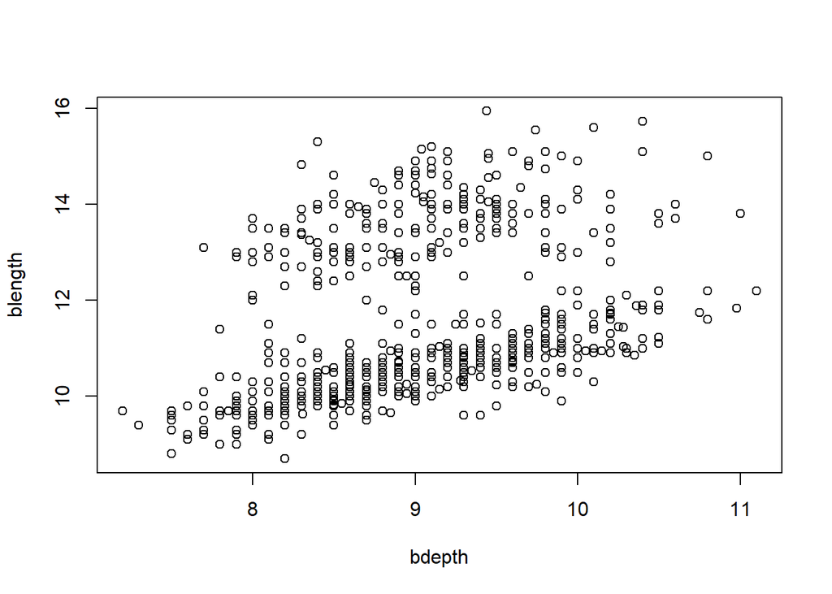

```r
plot(blength~bdepth, data = finch)
```

2.6 Add a comment to your script telling me what you see.

```r
# Not graded.
# length and depth are positively related
# "small" and "large" group are probably the two different species
```

## Problem 3 - modifying the data

3.1 Filter the data to include all individuals which had `blength` $\ge$ 15 mm.

```r
filter(finch, blength >= 15)
```

```
   year  band  species blength bdepth
1  2012 19652 scandens   15.00  10.80
2  2012 21347 scandens   15.20   9.10
3  1975   353 scandens   15.10   9.80
4  1975   412 scandens   15.20   9.10
5  1975   429 scandens   15.10   9.20
6  1975   460 scandens   15.00   9.90
7  1975   469 scandens   15.30   8.40
8  1975   472 scandens   15.10  10.40
9  1975   478 scandens   15.10   9.60
10 1975   571 scandens   15.60  10.10
11 1975  1014 scandens   15.54   9.74
12 1975  1841 scandens   15.73  10.40
13 1975  2084 scandens   15.94   9.44
14 1975  2397 scandens   15.14   9.04
15 1975 20266 scandens   15.05   9.45
```

```r
# 15 individuals or rows
```

3.2 Add a comment telling me how many individuals (rows) the above code returned. In addition, which species and years are in this subset of the data?

```r
# 15 rows/individuals
# Only scandens
# mostly 1975, but a few from 2012
```

3.3 Filter the data to include all individuals which are in the “fortis” species and have `bdepth` which are $<$ 8 mm. Also add a comment telling me how many rows this returns.

```r
filter(finch,
       species == "fortis",
       bdepth < 8)
```

```
   year  band species blength bdepth
1  2012 19032  fortis     9.3   7.50
2  2012 19072  fortis     9.6   7.80
3  2012 19114  fortis     9.8   7.70
4  2012 19226  fortis     9.7   7.50
5  2012 19263  fortis    10.0   7.90
6  2012 19328  fortis     9.5   7.70
7  2012 19382  fortis     9.8   7.70
8  2012 19392  fortis     9.2   7.70
9  2012 19623  fortis     9.1   7.60
10 2012 19682  fortis     9.7   7.80
11 2012 19782  fortis     9.2   7.60
12 2012 19878  fortis    10.1   7.70
13 2012 19947  fortis    10.4   7.90
14 2012 19952  fortis    10.1   7.70
```

[output cut: 21 more lines]

```r
# 35 rows
```

3.4 Filter the data to return all individuals which have `blength` exactly equal to 10 or 12 mm.

- Note that this should return exactly 23 rows.

```r
filter(finch,
       blength == 10 |
         blength == 12)
```

```
   year  band  species blength bdepth
1  2012 19022   fortis      10    8.5
2  2012 19263   fortis      10    7.9
3  2012 19274   fortis      10    8.3
4  2012 19280   fortis      10    8.9
5  2012 19372   fortis      10    8.4
6  2012 19482   fortis      10    8.4
7  2012 19889   fortis      10    8.4
8  2012 19914   fortis      10    8.5
9  2012 21090   fortis      10    8.2
10 2012 21244   fortis      10    8.5
11 2012 21249   fortis      10    8.3
12 2012 19122 scandens      12    8.7
13 2012 19406 scandens      12    8.0
14 1975   427   fortis      12   10.2
15 1975   453   fortis      10    8.7
16 1975   503   fortis      10    9.1
17 1975   519   fortis      10    8.3
18 1975   521   fortis      10    9.0
19 1975   567   fortis      10    8.4
20 1975   578   fortis      10    9.1
21 1975   602   fortis      10    8.6
22 1975   717   fortis      10    8.2
23 1975   811   fortis      10    8.6
```

## GRADED

3.5 Recall that the `year` column is an integer. Create a new object called `finch_year` which has the `year` column stored as a factor and have the levels be in the order of 1975 and then 2012. Print the new `finch_year` in your console as a tibble.

```r
### GRADED 0.5 points ####
# check that year has <fct> in the output
finch_year <- finch |>
  mutate(year = factor(year, levels = c("1975", "2012")))

finch_year |>
  as_tibble()
```

```
# A tibble: 651 × 5
   year   band species blength bdepth
   <fct> <int> <fct>     <dbl>  <dbl>
 1 2012  19022 fortis     10      8.5
 2 2012  19028 fortis     12.5    8.9
 3 2012  19032 fortis      9.3    7.5
 4 2012  19041 fortis     10.3    9.6
 5 2012  19044 fortis     11      9.2
 6 2012  19048 fortis     10.1    8.2
 7 2012  19072 fortis      9.6    7.8
 8 2012  19082 fortis     10.9    8.6
 9 2012  19104 fortis     10.3    8.4
10 2012  19114 fortis      9.8    7.7
# ℹ 641 more rows
```

- Remember to `ungroup()` at the end of your calculation

```r
### GRADED 0.5 points ####
finch_year_means <- finch_year |>
  group_by(species, year) |>
  summarize(m_depth = mean(bdepth),
            sd_depth = sd(bdepth),
            n_depth = n()) |>
  mutate(se_depth = sd_depth / sqrt(n_depth)) |>
  ungroup()

finch_year_means
```

```
# A tibble: 4 × 6
  species  year  m_depth sd_depth n_depth se_depth
  <fct>    <fct>   <dbl>    <dbl>   <int>    <dbl>
1 fortis   1975     9.17    0.737     316   0.0415
2 fortis   2012     8.61    0.733     121   0.0666
3 scandens 1975     8.96    0.567      87   0.0607
4 scandens 2012     9.19    0.669     127   0.0594
```

## Problem 4 - `ggplot`

4.1 Using `ggplot()` , make a histogram of `bdepth` where the fill is mapped to the species column.

- Be sure to use the original, unmodified `finch` data
- Also set `position = "identity"` and have `alpha` be some value $<$ 1

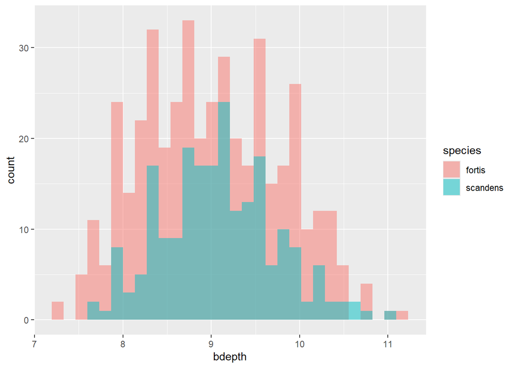

```r
ggplot(finch,
       aes(x = bdepth,
           fill = species)) +
  geom_histogram(position = "identity",
                 alpha = 0.5)
```

## GRADED

4.2 Make the same histogram as in 4.1, but this time:

- facet the data based on the year column
- Change the x-axis legend to say “Beak depth (mm)”
- Use one of the “viridis” color palettes
  - May need to modify the `begin` or `end` values to make the two groups visible.
- Use `theme_bw()`

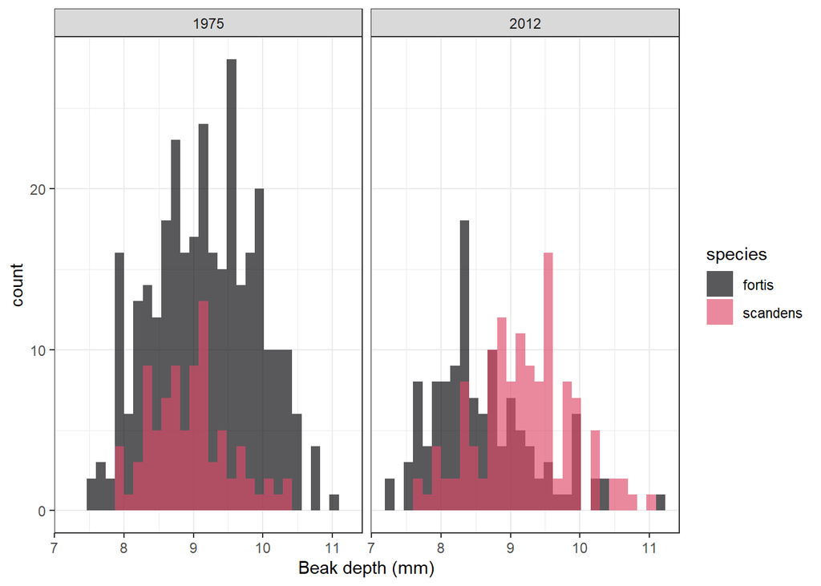

```r
### GRADED 0.5 points ####
ggplot(finch,
       aes(x = bdepth,
           fill = species)) +
  geom_histogram(position = "identity",
                 alpha = 0.65) +
  facet_wrap(.~year) +
  labs(x = "Beak depth (mm)") +
  scale_fill_viridis_d(option = "A",
                       end = 0.6) +
  theme_bw()
```

4.3 Using the `finch_year` data, make a boxplot of the `bdepth` data with:

- year on the x-axis
- fill according to species

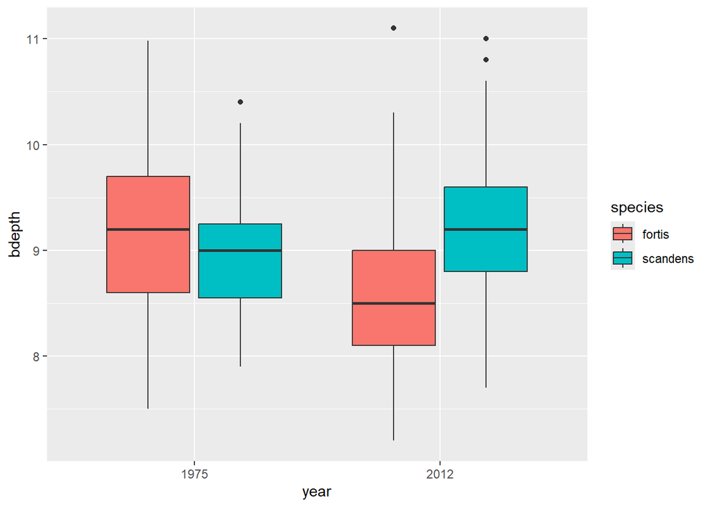

```r
ggplot(finch_year,
       aes(x = year,
           y = bdepth,
           fill = species)) +
  geom_boxplot()
```

## GRADED

4.4 Use the `finch_year_means` data to make a bar (column) graph showing the mean and SE of beak depth for each species and year combination. Also include:

- The arguments in `geom_col()` and `geom_errorbar()` should match what is in the lecture notes
- Choose a theme and a palette from Viridis
  - As before, make sure everything is visible by modifying the `begin` and `end` value accordingly.
- Change the y-axis label.
- Since the error bars are so small, you will also want to change the limits of the y-axis using `coord_cartesian()`.
  - Play around with the limits to make sure everything is visible.

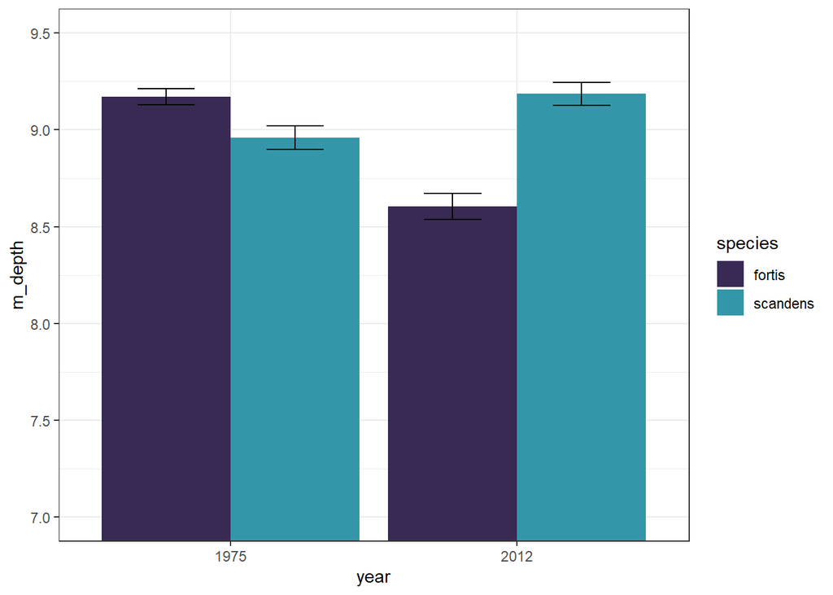

```r
### GRADED 0.5 points ####
ggplot(finch_year_means,
       aes(x = year,
           y = m_depth,
           ymin = m_depth - se_depth,
           ymax = m_depth + se_depth,
           fill = species)) +
  geom_col(position = "dodge") +
  geom_errorbar(position = position_dodge(0.9),
                width = 0.4) +
  theme_bw() +
  scale_fill_viridis_d(option = "G",
                       begin = 0.2,
                       end = 0.6) +
  coord_cartesian(ylim = c(7, 9.5))
```

4.5 Finally, using the `finch_year` data, make a scatter plot of beak length and depth. Use color, facets, etc. to show how this relationship varies with all combinations of year and species.

- Note there are a number of ways to do this and you are free to Choose.
- All graphs need to have the following:
  - Appropriate axis titles (reminder that length and depth are both recorded in mm)
  - Some way to distinguish all 4 groups
    - Scandens and fortis in both 1975 and 2012
  - Some theme and some viridis scale

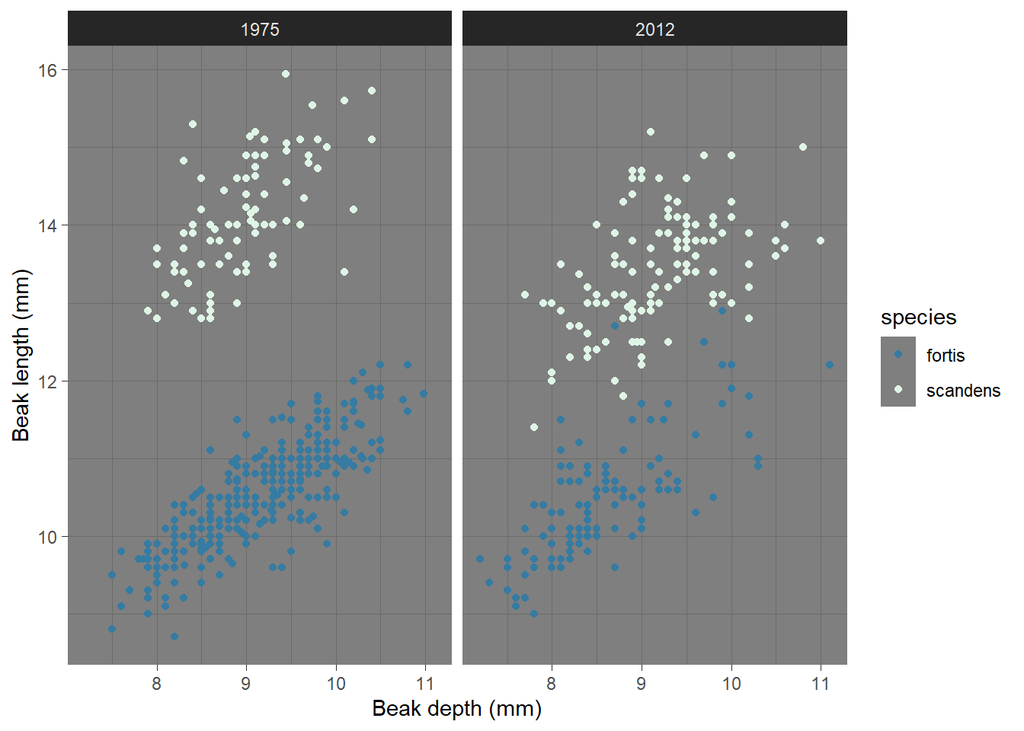

```r
ggplot(finch_year,
       aes(
         y = blength,
         x = bdepth,
         color = species)) +
  geom_point(
             size = 1.5) +
  facet_wrap(.~year)+
  labs(y = "Beak length (mm)",
       x = "Beak depth (mm)") +
  theme_dark() +
  scale_color_viridis_d(option = "G",
                        begin = 0.5)
```

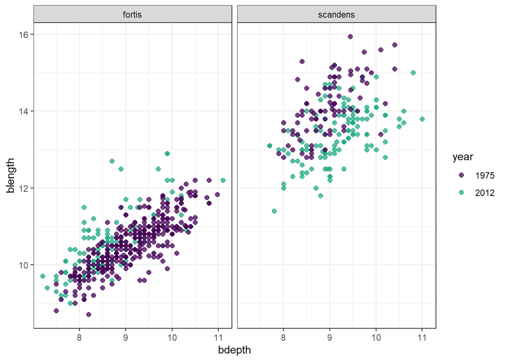

```r
ggplot(finch_year,
       aes(
         y = blength,
         x = bdepth,
         color = year)) +
  geom_point(alpha = 0.75,
             size = 2) +
  facet_wrap(.~species) +
  scale_color_viridis_d(end = 0.6) +
  theme_bw()
```

# Supplemental Information

**Note on the finch data**

For this homework assignment, we will be working with real data from [“Darwin’s Finches”](https://en.wikipedia.org/wiki/Darwin%27s_finches) in the Galapagos Islands. Famously, the variation in beak sizes of these birds is one of the observations which is often credited to Darwin’s formulation of his Theory of Natural Selection (although in reality he just [brought back finch](https://www.sciencehistory.org/distillations/darwins-barnacles#:~:text=But%20the%20truth%20is%2C%20Darwin,an%20expert%20back%20in%20England) specimens, and museum archivists were the ones to realize the diversity of species on the islands).

[figure not shown]

Darwin’s Finches. Figure By John Gould (14.Sep.1804 - 3.Feb.1881) - From “Voyage of the Beagle”. Public Domain, available [here](http://darwin-online.org.uk/converted/published/1845_Beagle_F14/1845_Beagle_F14_fig07.jpg)

The beaks of the Galapagos finches was the primary detail of interest. For birds, beaks are the primary tool at their disposal, and the type (size, shape, etc.) of beak you have determines what type of food resources that are available to you, and the types of “jobs” you can do.

Regardless of Darwin’s personal affinity (or lack thereof) for these birds, they have nonetheless played an outsized role in the history of biology. In more recent times, Drs. Peter and Rosemary Grant have spent decades on the islands following the birds through time and documenting changes in Finch morphology in response to drought and other environmental conditions. Their work has been well documented, including in the popular science book [*Beak of the finch*](https://www.goodreads.com/en/book/show/125286.The_Beak_of_the_Finch) by Jonathan Weiner, and much of this work is summarized in an [educational documentary on HHMI](https://youtu.be/mcM23M-CCog).

In this homework assignment, we will be working with a subset of the Grants’ beak measurement data for two of the species, *Geospiza fortis*, and *G. scandens*, collected on Daphne Major Island in 1975 and 2012. The full data set is available at [Data Dryad](https://datadryad.org/stash/dataset/doi:10.5061/dryad.g6g3h)